# DATS 6101 Midterm Project

Venkatesh Nagarjuna, Diluni Peiris, Manoj Kodihalli Venkatesh, Jose Luis Garcia Montero, Ella Brown

2025-03-19

Loading Libraries

```r
library(ggplot2)
library(tidyr)
library(dplyr)
library(gridExtra)
library(corrplot)
library(tidyverse)
library(caret)
library(readr)
library(cluster)
library(factoextra)
```

Reading the Data

```r
fitnessdf <- data.frame(read.csv("../dataset/workout_fitness_tracker_data.csv"))
```

**Data Pre-processing** * Removing Redundant Columns * Renaming Columns * Updating Data Types * Imputation * Handling Outliers * Feature Creation

**Removing Redundant Columns** The following columns will be removed from the dataset. User ID: Unique entries Water Intake (liters), VO2 Max and Body Fat (%): Redundant data (same value repeated)

```r
fitnessdf_cleaned <- fitnessdf[, !names(fitnessdf) %in% c("User.ID", "Water.Intake..liters.", "VO2.Max", "Body.Fat....")]
```

```r
str(fitnessdf_cleaned)
```

**Renaming Columns**

```r
colnames(fitnessdf_cleaned)<- c("Age", "Gender","Height_cm","Weight_kg","Workout_Type","Workout_Duration_mins","Calories_Burned",                   "Heart_Rate_bpm","Steps_Taken","Distance_km","Workout_Intensity","Sleep_Hours","Daily_Calories_Intake",      "Resting_Heart_Rate_bpm","Mood_Before_Workout","Mood_After_Workout")
```

**Updating Data Types**

```r
factor_cols <- c("Gender",
                 "Workout_Type",
                 "Workout_Intensity",
                 "Mood_Before_Workout",
                 "Mood_After_Workout")

fitnessdf_cleaned[factor_cols] <- lapply(fitnessdf_cleaned[factor_cols], function(x) as.factor(x))
str(fitnessdf_cleaned)
```

**Imputation**

```r
missing_report <- data.frame(
  Column = names(fitnessdf_cleaned),
  Missing_Count = colSums(is.na(fitnessdf_cleaned)),
  Missing_Percentage = colSums(is.na(fitnessdf_cleaned)) / nrow(fitnessdf_cleaned) * 100
  )

print(missing_report)
```

*There are no missing values in the dataset.

**Handling Outliers**

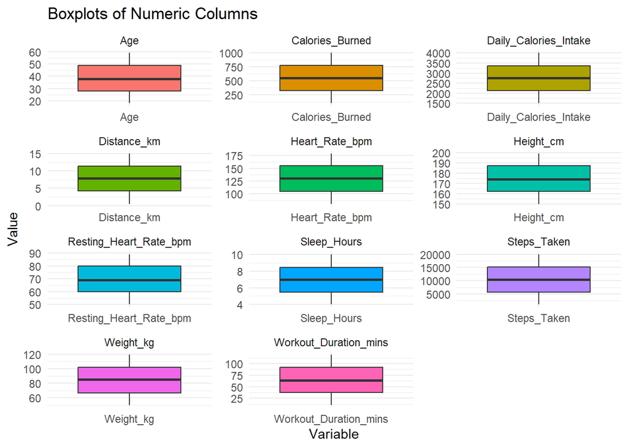

```r
# Select numeric columns
fitnessdf_numeric <- fitnessdf_cleaned %>% select(where(is.numeric))

# Convert to long format
fitnessdf_long <- fitnessdf_numeric %>% pivot_longer(
  cols = everything(),
  names_to = "Variable",
  values_to = "Value"
)

# Create box plots in a grid layout
ggplot(fitnessdf_long, aes(x = Variable, y = Value, fill = Variable)) +
  geom_boxplot(outlier.color = "red", outlier.shape = 16, outlier.size = 3) +
  theme_minimal() +
  labs(title = "Boxplots of Numeric Columns") +
  theme(legend.position = "none") +
  facet_wrap(~Variable, scales = "free",ncol= 3)  # Creates a grid of individual plots
```

Detecting outliers using Z-score.

```r
# Detecting outliers by Z-score
zscore_outliers <- function(df, threshold = 3) {
  outliers <- data.frame(Row = integer(), Column = character(), Value = numeric())

  for (col in colnames(df)) {
    if (is.numeric(df[[col]])) {
      z_scores <- scale(df[[col]])
      rows <- which(abs(z_scores) > threshold)

      if (length(rows) > 0) {
        for (r in rows) {
          outliers <- rbind(outliers, data.frame(Row = r, Column = col, Value = df[r, col]))
        }
      }
    }
  }

  return(outliers)
}

# Detect outliers using Z-score
outliers_z <- zscore_outliers(fitnessdf_cleaned)
print("Outliers detected using Z-score:")
print(outliers_z)
```

No outliers were observed in the data.

**Feature Creation** BMI: To categorize the dataset based on BMI categroies as Underweight, Normal, Overweight and Obese BMI Category: Four classes as Underweight, Normal, Overweight and Obese Age Groups: Based on the dataset(Ages 18-59), 18-30 years (Youth), 31-45 (Middle age), 46-59 (Senior)

**BMI**

```r
fitnessdf_cleaned$BMI <- fitnessdf_cleaned$Weight_kg / (fitnessdf_cleaned$Height_cm / 100)^2
```

**BMI Category**

Segmenting the data based on BMI

```r
fitnessdf_cleaned <- fitnessdf_cleaned %>%
  mutate(BMI_category= case_when(
     BMI < 18.5 ~ "Underweight",
     BMI >= 18.5 & BMI < 24.9 ~ "Normal",
     BMI >= 24.9 & BMI < 29.9 ~ "Overweight",
     BMI >= 29.9 ~ "Obese"

  ))

fitnessdf_cleaned$BMI_category <- factor(fitnessdf_cleaned$BMI_category, levels = c("Underweight", "Normal", "Overweight","Obese"))
```

**Age Groups**

Age Groups: Based on the dataset(Ages 18-59), 18-30 years (Youth), 31-45 (Middle age), 46-59 (Senior)

```r
fitnessdf_cleaned <- fitnessdf_cleaned %>%
  mutate(Age_group= case_when(
     Age <= 30 ~ "Youth (<= 30 years)",
     Age >= 31 & Age <= 45 ~ "Middle aged (31 to 45 years)",
     Age >= 46 ~ "Seniors (>= 46 years)"
  ))

fitnessdf_cleaned$Age_group <- factor(fitnessdf_cleaned$Age_group, levels = c("Youth (<= 30 years)", "Middle aged (31 to 45 years)", "Seniors (>= 46 years)"))
```

##EDA

### EDA: Demographic Analysis

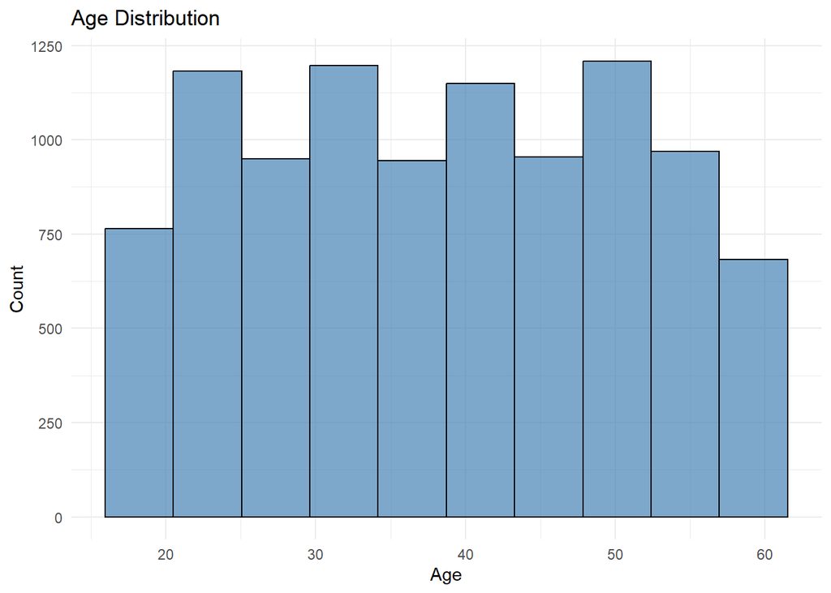

```r
# Summary statistics for demographic variables
demographics_summary <- fitnessdf_cleaned %>%
  select(Age, Gender, Height_cm, Weight_kg, BMI_category) %>%
  summary()
print(demographics_summary)

# Age Distribution Histogram
ggplot(fitnessdf_cleaned, aes(x = Age)) +
  geom_histogram(bins = 10, fill = "steelblue", color = "black", alpha = 0.7) +
  labs(title = "Age Distribution", x = "Age", y = "Count") +
  theme_minimal()
```

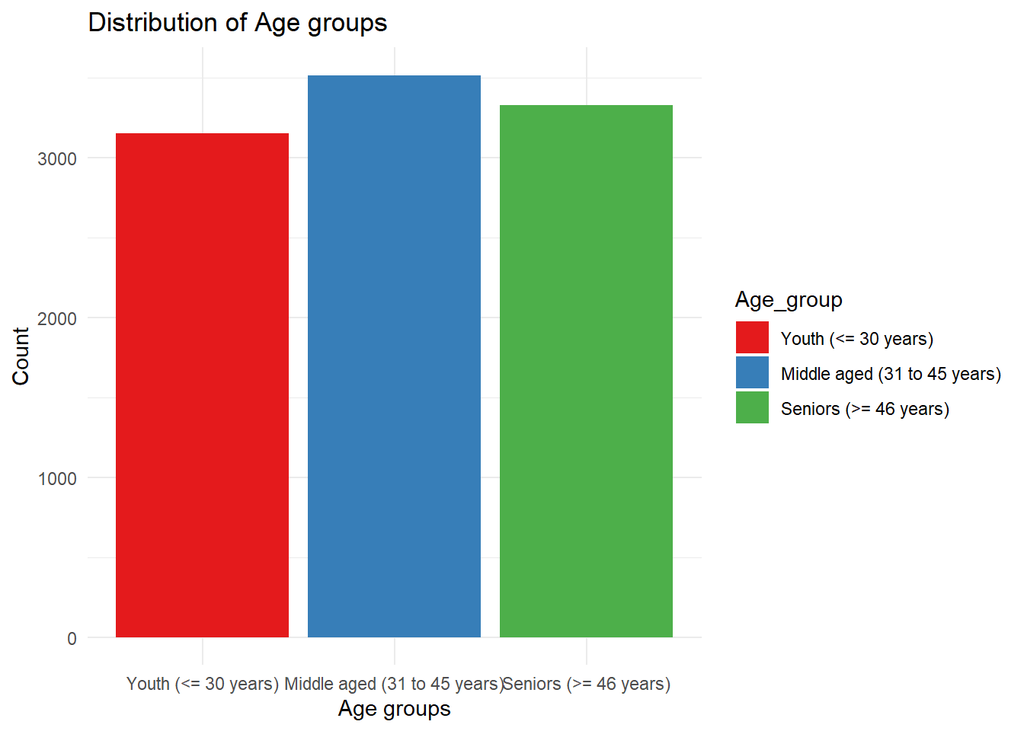

```r
# Age Category distribution
ggplot(fitnessdf_cleaned, aes(x = Age_group, fill = Age_group)) +
  geom_bar() +
  labs(title = "Distribution of Age groups", x = "Age groups", y = "Count") +
  theme_minimal() +
  scale_fill_brewer(palette = "Set1")
```

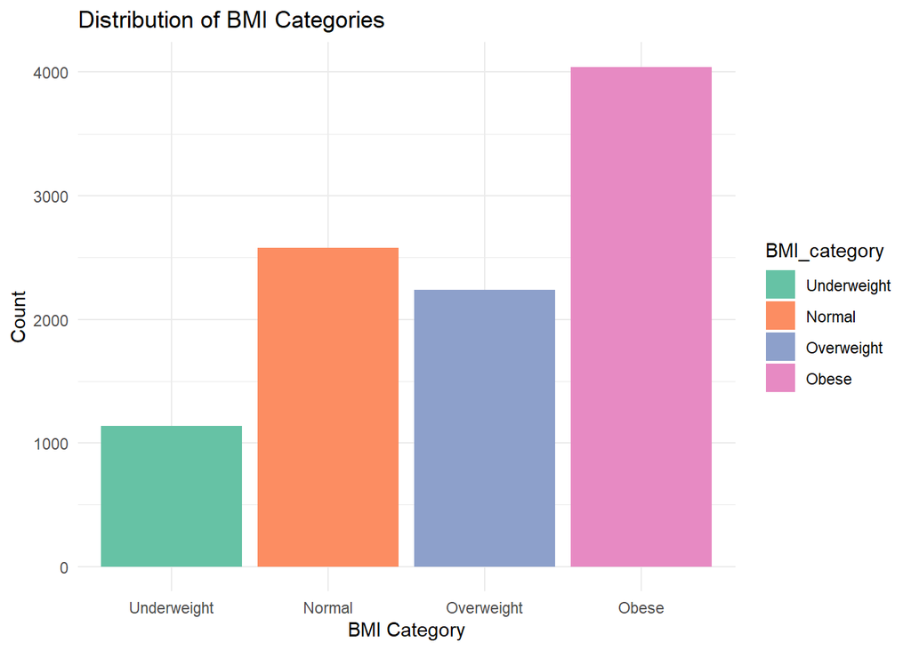

```r
#BMI- Category Distibution
ggplot(fitnessdf_cleaned, aes(x = BMI_category, fill = BMI_category)) +
  geom_bar() +
  labs(title = "Distribution of BMI Categories", x = "BMI Category", y = "Count") +
  theme_minimal() +
  scale_fill_brewer(palette = "Set2")  # Adds nice colors
```

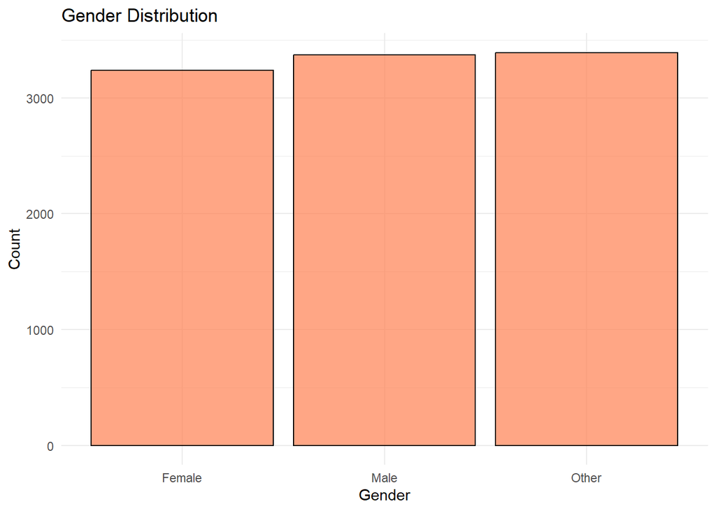

```r
# Gender Distribution Bar Plot (if the 'gender' column exists)
ggplot(fitnessdf_cleaned, aes(x = Gender)) +
    geom_bar(fill = "coral", color = "black", alpha = 0.7) +
    labs(title = "Gender Distribution", x = "Gender", y = "Count") +
    theme_minimal()
```

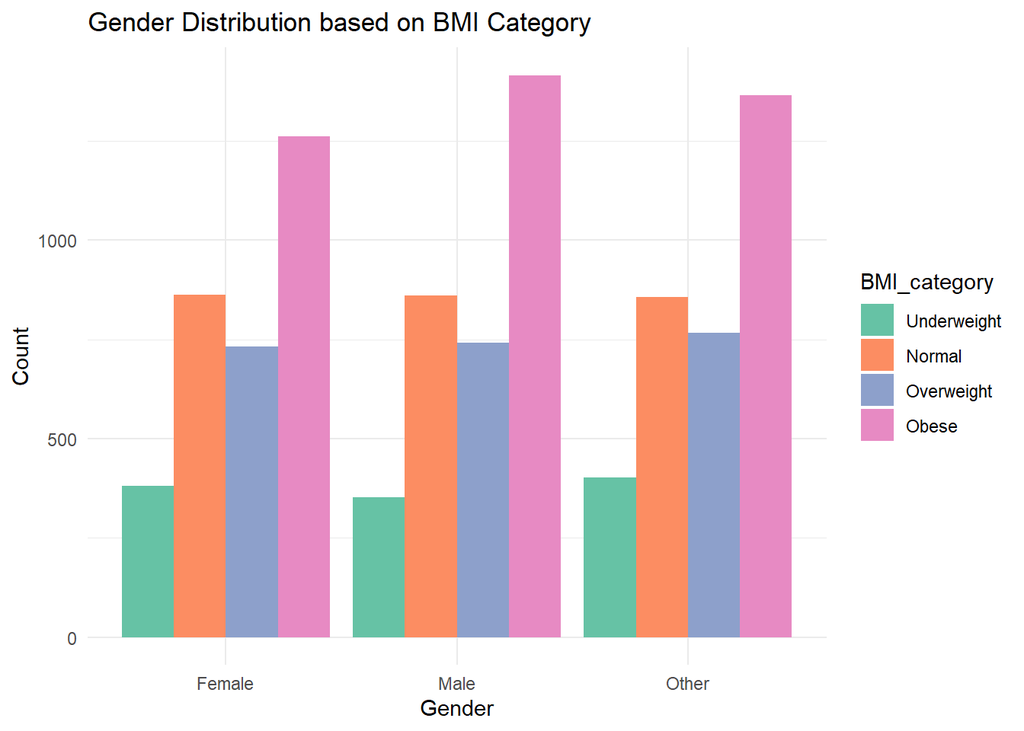

```r
# Gender Distribution based on BMI Category
ggplot(fitnessdf_cleaned,aes(x=Gender, fill= BMI_category))+
  geom_bar(position = "dodge")+
  labs(title = "Gender Distribution based on BMI Category", x = "Gender", y = "Count")+
  theme_minimal()+
  scale_fill_brewer(palette = "Set2")
```

### EDA: Performance Metrics

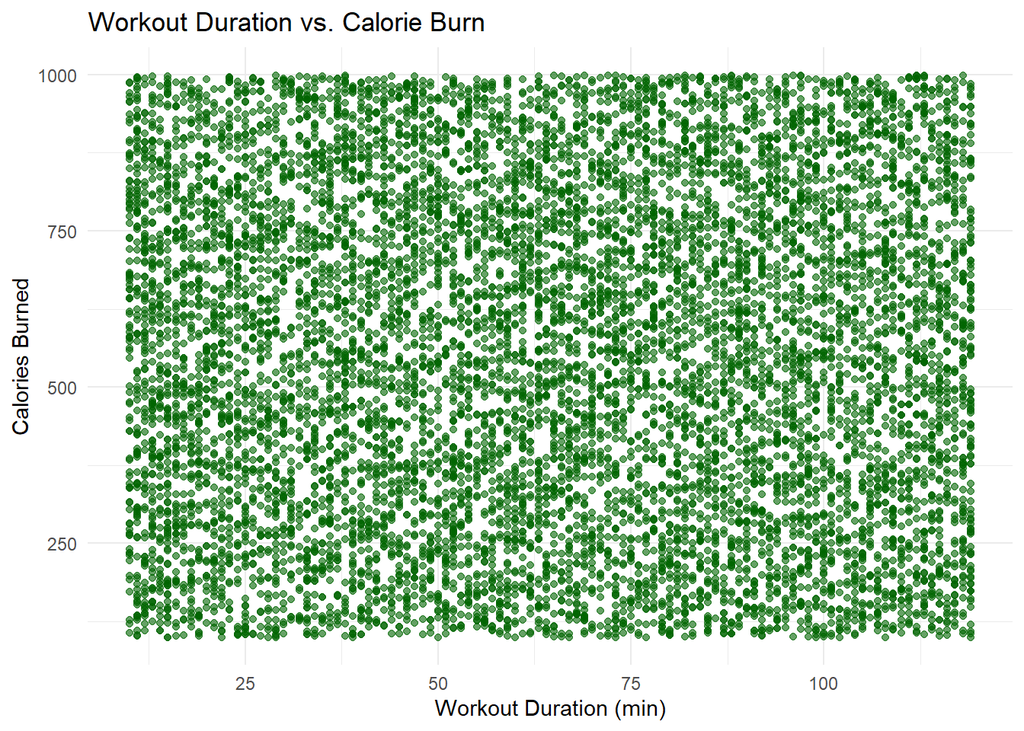

```r
# Summary statistics for performance metrics
performance_summary <- fitnessdf_cleaned %>%
  select(Workout_Duration_mins, Calories_Burned, Heart_Rate_bpm) %>%
  summary()
print(performance_summary)

# Scatter Plot: Workout Duration vs. Calorie Burn
if(all(c("Workout_Duration_mins", "Calories_Burned") %in% colnames(fitnessdf_cleaned))){
  ggplot(fitnessdf_cleaned, aes(x = Workout_Duration_mins, y = Calories_Burned)) +
    geom_point(alpha = 0.6, color = "darkgreen") +
    labs(title = "Workout Duration vs. Calorie Burn",
         x = "Workout Duration (min)", y = "Calories Burned") +
    theme_minimal()
}
```

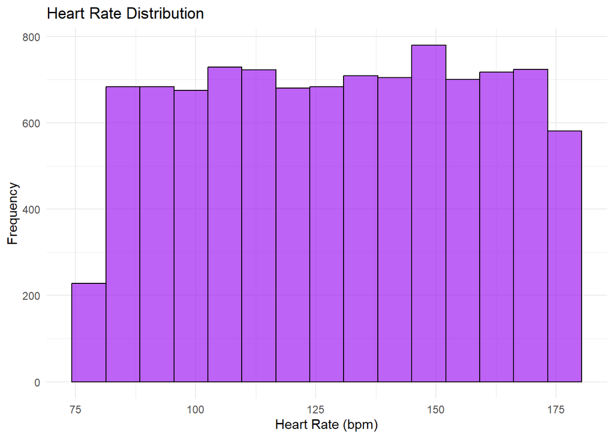

```r
# Heart Rate Distribution Histogram
ggplot(fitnessdf_cleaned, aes(x = Heart_Rate_bpm)) +
    geom_histogram(bins = 15, fill = "purple", color = "black", alpha = 0.7) +
    labs(title = "Heart Rate Distribution",
         x = "Heart Rate (bpm)", y = "Frequency") +
    theme_minimal()
```

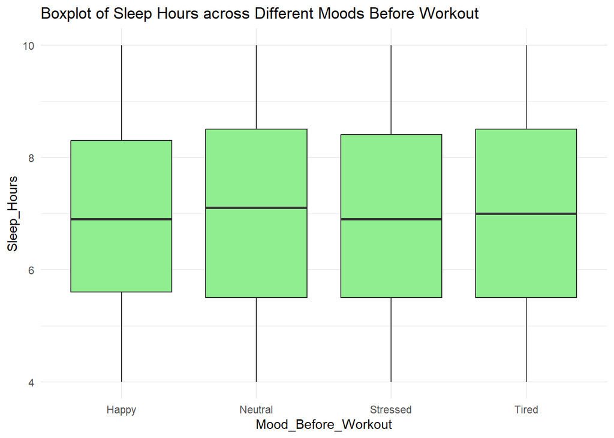

```r
#Boxplot: Mood before workout and sleep hours
ggplot(fitnessdf_cleaned, aes(y = Sleep_Hours, x= Mood_Before_Workout)) +
  geom_boxplot(outlier.colour = "red", outlier.shape=16, outlier.size=4, fill = "#90EE90")+
  labs(title = "Boxplot of Sleep Hours across Different Moods Before Workout", x = "Mood_Before_Workout", y = "Sleep_Hours") +
  theme_minimal()
```

### EDA: Workout Patterns

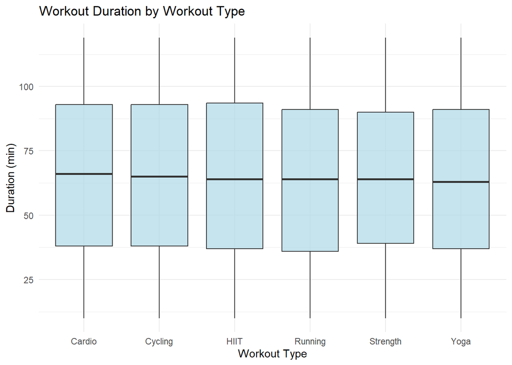

```r
# Frequency of Workout Types (if the 'workout_type' column exists)
if("Workout_Type" %in% colnames(fitnessdf_cleaned)){
  ggplot(fitnessdf_cleaned, aes(x = Workout_Type)) +
    geom_bar(fill = "orange", color = "black", alpha = 0.7) +
    labs(title = "Frequency of Workout Types",
         x = "Workout Type", y = "Count") +
    theme_minimal()

  # Boxplot: Workout Duration by Workout Type
  ggplot(fitnessdf_cleaned, aes(x = Workout_Type, y = Workout_Duration_mins)) +
    geom_boxplot(fill = "lightblue", alpha = 0.7) +
    labs(title = "Workout Duration by Workout Type",
         x = "Workout Type", y = "Duration (min)") +
    theme_minimal()
}
```

## EDA: Gender Mean differences

```r
fitnessdf_gender <- fitnessdf_cleaned %>%
  filter(Gender %in% c("Male", "Female"))

gender_summaries <- fitnessdf_gender %>%
  group_by(Gender) %>%
  summarise(
    count = n(),
    mean_height = mean(Height_cm),
    sd_height = sd(Height_cm),
    mean_weight = mean(Weight_kg),
    sd_weight = sd(Weight_kg),
    mean_calories = mean(Calories_Burned),
    sd_calories = sd(Calories_Burned),
    mean_duration = mean(Workout_Duration_mins),
    sd_duration = sd(Workout_Duration_mins)
  )

print("Summary Statistics by Gender:")
print(gender_summaries)

# Perform t-tests for various metrics
t_test_results <- list(
  Height = t.test(Height_cm ~ Gender, data = fitnessdf_gender),
  Weight = t.test(Weight_kg ~ Gender, data = fitnessdf_gender),
  Duration = t.test(Workout_Duration_mins ~ Gender, data = fitnessdf_gender),
  Calories = t.test(Calories_Burned ~ Gender, data = fitnessdf_gender),
  Heart_Rate = t.test(Heart_Rate_bpm ~ Gender, data = fitnessdf_gender),
  Steps = t.test(Steps_Taken ~ Gender, data = fitnessdf_gender),
  Distance = t.test(Distance_km ~ Gender, data = fitnessdf_gender),
  Sleep = t.test(Sleep_Hours ~ Gender, data = fitnessdf_gender),
  Daily_Calories = t.test(Daily_Calories_Intake ~ Gender, data = fitnessdf_gender),
  Resting_HR = t.test(Resting_Heart_Rate_bpm ~ Gender, data = fitnessdf_gender)
)

# Create a summary table of t-test results
t_test_summary <- data.frame(
  Variable = names(t_test_results),
  P_Value = sapply(t_test_results, function(x) x$p.value),
  Mean_Difference = sapply(t_test_results, function(x) diff(x$estimate)),
  T_Statistic = sapply(t_test_results, function(x) x$statistic)
)

# Add significance indicators
t_test_summary$Significance <- ifelse(t_test_summary$P_Value < 0.001, "***",
                                    ifelse(t_test_summary$P_Value < 0.01, "**",
                                           ifelse(t_test_summary$P_Value < 0.05, "*", "ns")))

print("T-Test Results Summary:")
print(t_test_summary)
```

##Statistical Testing **SMART Q1** What combination of workout types and durations maximizes calorie burn efficiency for different user profiles (clustered by age, BMI, and fitness level)?

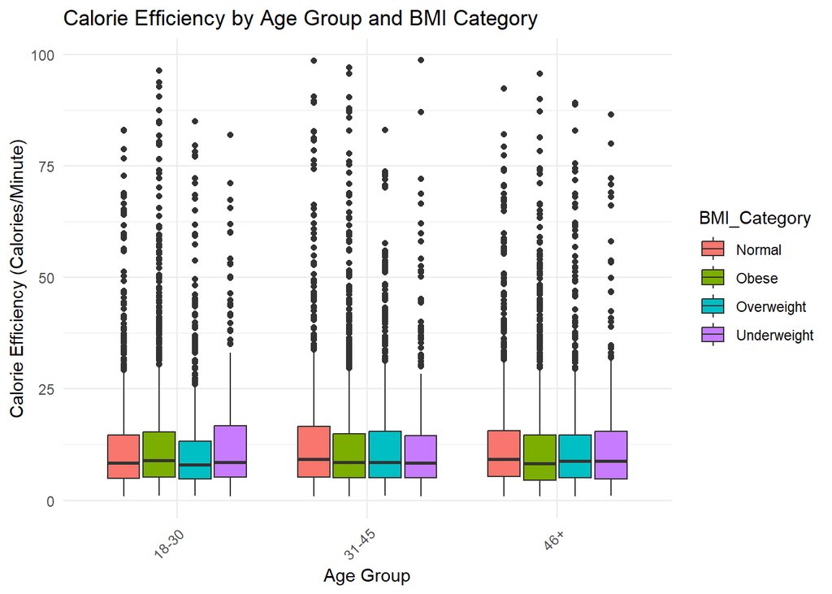

```r
# Calculate BMI and create age groups (I'm hardcoding some things to fit it from my own file)
fitnessdf_cleaned <- fitnessdf_cleaned %>%
  mutate(
    BMI = Weight_kg / ((Height_cm / 100)^2),
    BMI_Category = case_when(
      BMI < 18.5 ~ "Underweight",
      BMI >= 18.5 & BMI < 25 ~ "Normal",
      BMI >= 25 & BMI < 30 ~ "Overweight",
      BMI >= 30 ~ "Obese"
    ),
    Calorie_Efficiency = Calories_Burned / Workout_Duration_mins,
    Age_group = case_when(
      Age <= 30 ~ "18-30",
      Age > 30 & Age <= 45 ~ "31-45",
      Age > 45 ~ "46+"
    )
  )

# Visualize the data
ggplot(fitnessdf_cleaned, aes(x = Age_group, y = Calorie_Efficiency, fill = BMI_Category)) +
  geom_boxplot() +
  labs(title = "Calorie Efficiency by Age Group and BMI Category",
       x = "Age Group",
       y = "Calorie Efficiency (Calories/Minute)") +
  theme_minimal() +
  theme(axis.text.x = element_text(angle = 45, hjust = 1))
```

```r
# Linear regression including BMI category
model <- lm(Calorie_Efficiency ~ Workout_Duration_mins + Workout_Type + Age + BMI_Category,
            data = fitnessdf_cleaned)
print(summary(model))
```

**SMART Q2**

How does the relationship between heart rate patterns and calorie burn vary across different workout types, and can this predict optimal workout intensity?

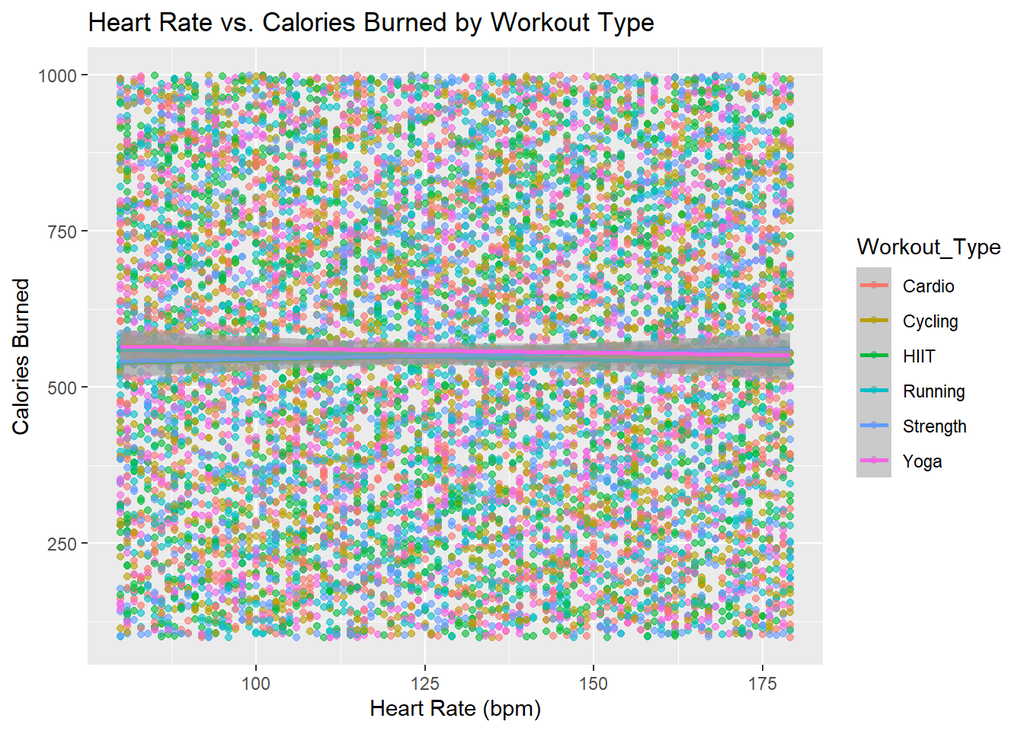

```r
ggplot(fitnessdf_cleaned, aes(x = Heart_Rate_bpm, y = Calories_Burned, color = Workout_Type)) +
  geom_point(alpha=0.6) +
  geom_smooth(method = 'lm') +
  labs(title = "Heart Rate vs. Calories Burned by Workout Type",
       x = "Heart Rate (bpm)",
       y = "Calories Burned")
```

```r
# Find optimal intensity based on calories per heart rate
optimal_intensity <- fitnessdf_cleaned %>%
  mutate(Efficiency = Calories_Burned / Heart_Rate_bpm) %>%
  group_by(Workout_Type, Workout_Intensity) %>%
  summarise(Avg_Efficiency =  round(mean(Efficiency, na.rm = TRUE), 2)) %>%
  arrange(Workout_Type, desc(Avg_Efficiency))

# Display optimal intensity results
print(optimal_intensity)
```

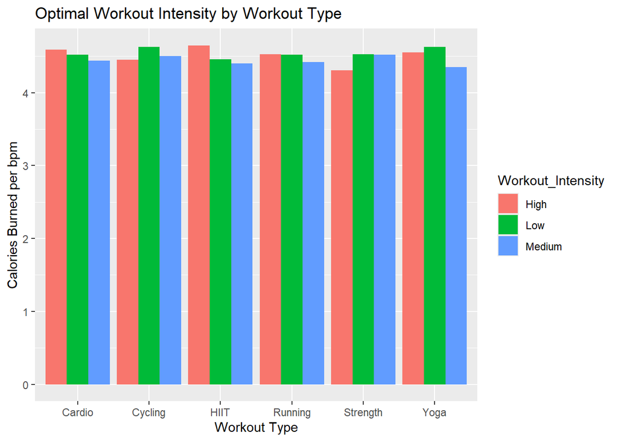

```r
# Visualization of optimal intensities
ggplot(optimal_intensity, aes(x=Workout_Type, y=Avg_Efficiency, fill=Workout_Intensity)) +
  geom_bar(stat="identity", position="dodge") +
  labs(title="Optimal Workout Intensity by Workout Type",
       x="Workout Type",
       y="Calories Burned per bpm")
```

```r
# Statistical modeling: Create regression models for each Workout_Type
models <- fitnessdf_cleaned %>%
  group_by(Workout_Type) %>%
  nest() %>%
  mutate(model = map(data, ~ lm(Calories_Burned ~ Heart_Rate_bpm + Workout_Intensity, data = .x)))

# Model summaries
models_summary <- models %>%
  mutate(tidied = map(model, broom::tidy)) %>%
  unnest(tidied)

print(models_summary)

# Evaluate Model Performance: R-squared values for each workout type
model_performance <- models %>%
  mutate(R_squared = map_dbl(model, ~summary(.)$r.squared)) %>%
  select(Workout_Type, R_squared)

print(model_performance)
```

Conclusion: No significant effect on workout intensity based on the heart rate and calories burned according to the dataset.

**SMART Q3**

Can we identify distinct user profiles based on their workout patterns using clustering analysis on workout duration, calorie burn, and heart rate?

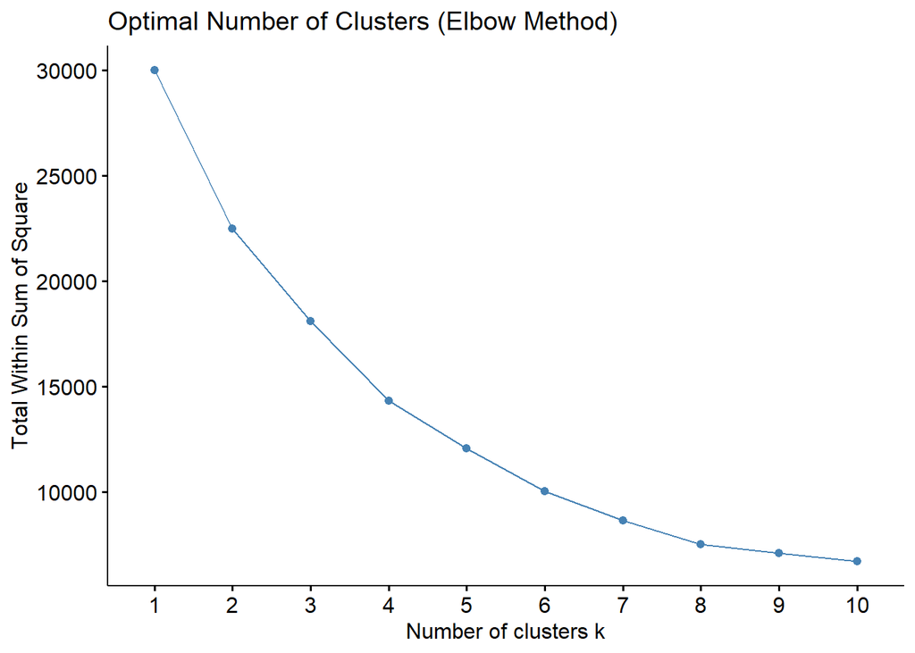

```r
cluster_data <- fitnessdf_cleaned %>%
  select(Workout_Duration_mins, Calories_Burned, Heart_Rate_bpm) %>%
  drop_na()

# Add index as unique identifier
cluster_data <- cluster_data %>%
  mutate(Index = row_number())

# Scale the data for clustering
scaled_data <- cluster_data %>%
  select(-Index) %>%
  scale()

# Determine optimal number of clusters using the elbow method
fviz_nbclust(scaled_data, kmeans, method = "wss") +
  labs(title = "Optimal Number of Clusters (Elbow Method)")
```

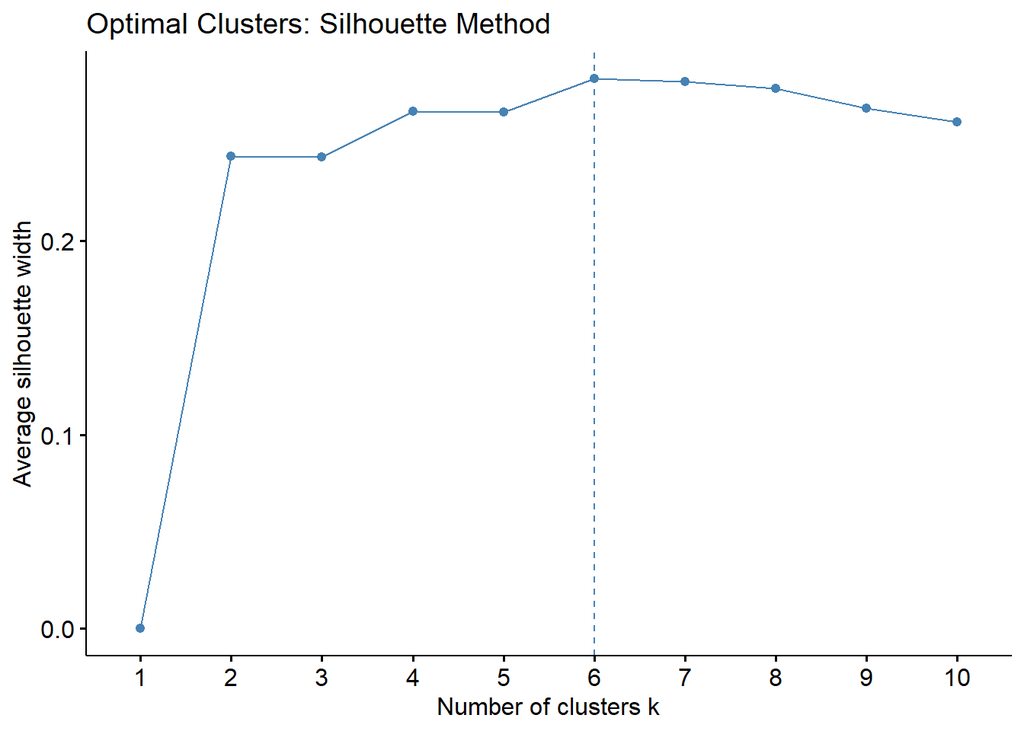

```r
# Determine optimal number of clusters using Silhouette Method
fviz_nbclust(scaled_data, kmeans, method = "silhouette") +
  labs(title = "Optimal Clusters: Silhouette Method")
```

[figure not shown]

```r
# Perform K-means clustering (Choose optimal k from silhouette results, e.g., k=3)
set.seed(123)
optimal_k <- 6  # Adjust based on silhouette/elbow plots
kmeans_result <- kmeans(scaled_data, centers = optimal_k, nstart = 25)

# Add cluster labels to original data
cluster_results <- cluster_data %>%
  mutate(Cluster = factor(kmeans_result$cluster))

# Visualize clusters using PCA
fviz_cluster(kmeans_result, data = scaled_data,
             ellipse.type = "euclid",
             repel = TRUE,
             ggtheme = theme_minimal()) +
  labs(title = "Workout Patterns Clustering")
```

```r
# Summarize each cluster's characteristics
cluster_summary <- cluster_results %>%
  group_by(Cluster) %>%
  summarise(
    Count = n(),
    Avg_Workout_Duration = round(mean(Workout_Duration_mins), 2),
    Avg_Calories_Burned = round(mean(Calories_Burned), 2),
    Avg_Heart_Rate = round(mean(Heart_Rate_bpm), 2)
  )

# Display summary
print(cluster_summary)
```

Cluster characteristics:

Cluster 1 (Moderate Duration, Low Calorie, High Intensity): - High intensity, cardio-focused workouts

Cluster 2 (Moderate Duration, High Calorie, Low Intensity): - Very high calorie burn - Low intensity, strength-focused or resistance workouts

Cluster 3 (Short Duration, High Calorie, High Intensity): - Short but intense workouts, possibly HIIT

Cluster 4 (Long Duration, High Calorie, High Intensity): - Extended cardio or endurance sessions

Cluster 5 (Short Duration, Low Calorie, Moderate Intensity): - Short duration, moderate effort, possibly low-intensity cardio or stretching

Cluster 6 (Long Duration, Moderate Calorie, Low Intensity): - Extended low-intensity workouts, e.g., walking or yoga

**SMART Q4**

1. Effects of workout type on different BMI categories [Factorial ANOVA]

Factor 1: BMI Category - Underweight, Normal, Overweight and Obese

Factor 2 : Workout Type - Cycling, Cardio, HIIT, Strength, Yoga, Running

Dependent Variable: Calories_Burned

Main Effects

BMI Category:

$$H_0: \mu_{underweight} = \mu_{normal} = \mu_{overweight} = \mu_{obese}$$
$$H_1: \text{ At least one mean is different}$$

The calorie burn is the same for all BMI levels.

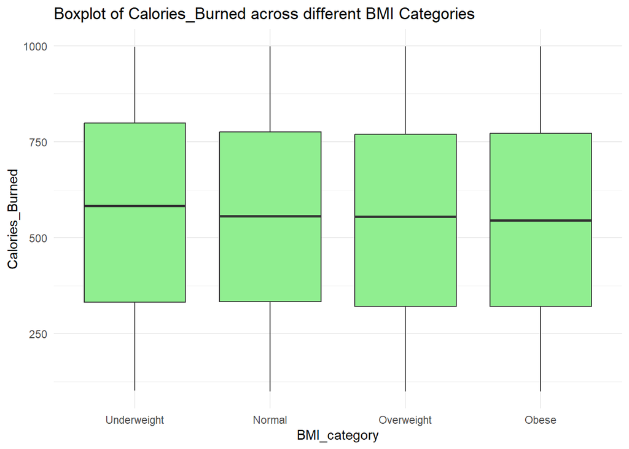

```r
#Boxplot: Calories_Burned across different BMI levels
ggplot(fitnessdf_cleaned, aes(y = Calories_Burned, x= BMI_category)) +
  geom_boxplot(outlier.colour = "red", outlier.shape=16, outlier.size=4, fill = "#90EE90")+
  labs(title = "Boxplot of Calories_Burned across different BMI Categories", x = "BMI_category", y = "Calories_Burned") +
  theme_minimal()
```

Workout Type:

$$H_0: \mu_{cycling} = \mu_{Cardio} = \mu_{HIIT} = \mu_{Strengh} =
\mu_{yoga} = \mu_{running}$$

$$H_1: \text{ At least one mean is different}$$

The calorie burn is the same for all workout types.

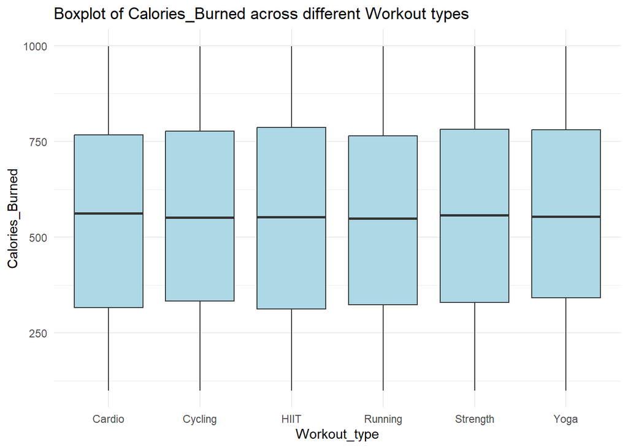

```r
#Boxplot: Boxplot ofCalories_Burned across different Workout types
ggplot(fitnessdf_cleaned, aes(y = Calories_Burned, x= Workout_Type)) +
  geom_boxplot(outlier.colour = "red", outlier.shape=16, outlier.size=4, fill = "lightblue")+
  labs(title = "Boxplot of Calories_Burned across different Workout types", x = "Workout_type", y = "Calories_Burned") +
  theme_minimal()
```

Interaction Effect

$$H_0: \text{There is no interaction between BMI level and workout type
on Calorie burn}$$

$$H_1: \text{There is an interaction between BMI level and workout type
on Calorie burn}$$

The workout type does not have an influence on Calorie burn based on BMI Levels.

```r
# Run factorial ANOVA
result <- aov(Calories_Burned ~ BMI_category * Workout_Type, data = fitnessdf_cleaned)
```

```r
# Run factorial ANOVA
summary(result)
```

Based on the Results;(Testing at 95% significance level)

1. Main effects

- BMI Level: Cannot Reject HO as P value is > 0.05,The average Calorie burn is equal among different BMI levels.
- Workout Type: Cannot Reject HO as P value is > 0.05, The average Calorie burn is equal among different Workout types.
2. Interaction Effect
- Cannot Reject HO as P value is > 0.05, Different BMI groups respond the same to different workout types.

**SMART Q5** Link between poor sleep and resting heart rate (fewer the hours of sleep and higher resting heart rate) Source: https://pmc.ncbi.nlm.nih.gov/articles/PMC7680518/

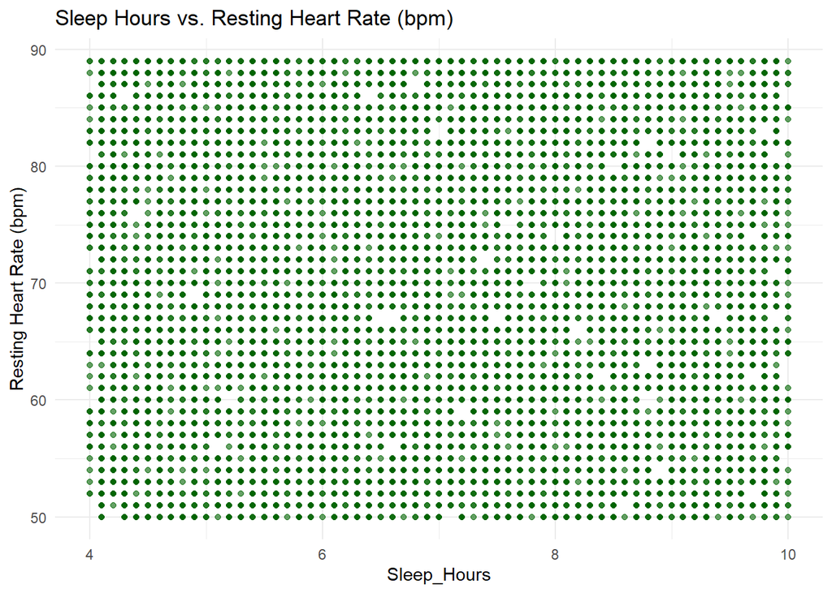

```r
# Scatter Plot
ggplot(fitnessdf_cleaned, aes(x = Sleep_Hours, y = Resting_Heart_Rate_bpm)) +
    geom_point(alpha = 0.6, color = "darkgreen") +
    labs(title = "Sleep Hours vs. Resting Heart Rate (bpm)",
         x = "Sleep_Hours", y = "Resting Heart Rate (bpm)") +
    theme_minimal()
```

```r
cor(fitnessdf_cleaned$Sleep_Hours,fitnessdf_cleaned$Resting_Heart_Rate_bpm)
```

Coefficient - -0.0125. It is negatively correlated as expected, however the strength of the relationship is low.

**SMART Q6** Is there a relationship between mood before and mood after workout?

Mood Before Workout: Happy, Neutral, Stressed and Tired.

Mood After Workout: Energized, Fatigued and Neutral

Using a Chi-squared test of Independence.

$$H_0: \text{There is no relationship between mood before and after
workout}$$

$$H_1: \text{There is a relationship between mood before and after
workout}$$

```r
# Creating a Contingency Table
table_data <- table(fitnessdf_cleaned$Mood_Before_Workout, fitnessdf_cleaned$Mood_After_Workout)
print(table_data)
```

```r
# Run Chi-Square Test
chi_sq_result <- chisq.test(table_data)
print(chi_sq_result)
```

P-value is > 0.05, Therefore we cannot reject the Null. There’s no relationship between mood before and after workout.